# Homework 7:PCA and Cluster analysis

# Q1: PCA

```r
Data<-read.csv("GCI_1.csv")
summary(Data[1:14])
```

```
##   Country.Code      Country       Pillar.1        Pillar.2
##  ALB    :  1   Albania  :  1   Min.   :2.094   Min.   :1.731
##  ARE    :  1   Algeria  :  1   1st Qu.:3.422   1st Qu.:3.074
##  ARG    :  1   Argentina:  1   Median :3.879   Median :4.037
##  ARM    :  1   Armenia  :  1   Mean   :4.049   Mean   :4.015
##  AUS    :  1   Australia:  1   3rd Qu.:4.467   3rd Qu.:4.808
##  AUT    :  1   Austria  :  1   Max.   :6.096   Max.   :6.687
##  (Other):134   (Other)  :134
##     Pillar.3        Pillar.4        Pillar.5        Pillar.6
##  Min.   :2.436   Min.   :2.861   Min.   :2.134   Min.   :2.812
##  1st Qu.:4.198   1st Qu.:4.943   1st Qu.:3.524   1st Qu.:4.042
##  Median :4.727   Median :5.712   Median :4.283   Median :4.296
##  Mean   :4.775   Mean   :5.496   Mean   :4.236   Mean   :4.356
##  3rd Qu.:5.380   3rd Qu.:6.193   3rd Qu.:4.968   3rd Qu.:4.638
##  Max.   :6.829   Max.   :6.868   Max.   :6.197   Max.   :5.715
##
##     Pillar.7        Pillar.8        Pillar.9       Pillar.10
##  Min.   :2.586   Min.   :2.238   Min.   :2.054   Min.   :1.400
##  1st Qu.:3.830   1st Qu.:3.419   1st Qu.:3.035   1st Qu.:2.968
##  Median :4.225   Median :3.853   Median :3.817   Median :3.815
##  Mean   :4.221   Mean   :3.911   Mean   :4.064   Mean   :3.886
##  3rd Qu.:4.520   3rd Qu.:4.404   3rd Qu.:4.973   3rd Qu.:4.770
##  Max.   :5.799   Max.   :5.728   Max.   :6.419   Max.   :6.978
##
##    Pillar.11       Pillar.12
##  Min.   :2.720   Min.   :2.226
##  1st Qu.:3.567   1st Qu.:3.031
##  Median :3.884   Median :3.276
##  Mean   :4.045   Mean   :3.520
##  3rd Qu.:4.349   3rd Qu.:3.744
##  Max.   :5.795   Max.   :5.764
##
```

```r
Data$GDP<-as.numeric(Data$GDP)
```

As first two variables are categorical, I will exclude them from the PCA analysis. Before running PCA analysis, I want to check what is correlation between variables.

```r
X<-Data[3:14]
cor(X, use="complete.obs", method="kendall")
```

```
##            Pillar.1  Pillar.2  Pillar.3  Pillar.4  Pillar.5  Pillar.6
## Pillar.1  1.0000000 0.5529291 0.3066804 0.4493320 0.4906475 0.6542652
## Pillar.2  0.5529291 1.0000000 0.3401850 0.6583762 0.6873587 0.6322713
## Pillar.3  0.3066804 0.3401850 1.0000000 0.2443988 0.2647482 0.3403905
## Pillar.4  0.4493320 0.6583762 0.2443988 1.0000000 0.7264132 0.5216855
## Pillar.5  0.4906475 0.6873587 0.2647482 0.7264132 1.0000000 0.5917780
## Pillar.6  0.6542652 0.6322713 0.3403905 0.5216855 0.5917780 1.0000000
## Pillar.7  0.4826310 0.3163412 0.2850976 0.2678314 0.3042138 0.4641316
## Pillar.8  0.5142857 0.4861254 0.3874615 0.3734841 0.4320658 0.6006166
## Pillar.9  0.4968140 0.7498458 0.3124358 0.6594039 0.7570401 0.6106886
## Pillar.10 0.1371017 0.3761562 0.2145940 0.3054471 0.3336074 0.2361768
## Pillar.11 0.5780062 0.6723535 0.2694758 0.5284687 0.6071942 0.6906475
## Pillar.12 0.5845838 0.6053443 0.2468654 0.5120247 0.5985612 0.6302158
##             Pillar.7  Pillar.8  Pillar.9  Pillar.10 Pillar.11 Pillar.12
## Pillar.1  0.48263104 0.5142857 0.4968140 0.13710175 0.5780062 0.5845838
## Pillar.2  0.31634121 0.4861254 0.7498458 0.37615622 0.6723535 0.6053443
## Pillar.3  0.28509764 0.3874615 0.3124358 0.21459404 0.2694758 0.2468654
## Pillar.4  0.26783145 0.3734841 0.6594039 0.30544707 0.5284687 0.5120247
## Pillar.5  0.30421377 0.4320658 0.7570401 0.33360740 0.6071942 0.5985612
## Pillar.6  0.46413155 0.6006166 0.6106886 0.23617677 0.6906475 0.6302158
## Pillar.7  1.00000000 0.3969168 0.3231244 0.04768756 0.3566290 0.3878726
## Pillar.8  0.39691675 1.0000000 0.4842754 0.27297020 0.5868448 0.5161357
## Pillar.9  0.32312436 0.4842754 1.0000000 0.32826310 0.6318602 0.5763618
## Pillar.10 0.04768756 0.2729702 0.3282631 1.00000000 0.3667009 0.3465570
## Pillar.11 0.35662898 0.5868448 0.6318602 0.36670092 1.0000000 0.7677287
## Pillar.12 0.38787256 0.5161357 0.5763618 0.34655704 0.7677287 1.0000000
```

As we can see from correlation matrix there are several groups of variables which are highly correlated(for example Pillar.9 is 2nd, 5th and 6th variables), so we’ve ensured that conducting PCA analysis for this dataset is reasonable.

```r
pca<-prcomp(Data[,3:14], center=T, scale=T)
summary(pca)
```

```
## Importance of components:
##                           PC1    PC2     PC3     PC4     PC5     PC6
## Standard deviation     2.8632 1.1052 0.88962 0.78502 0.54695 0.51217
## Proportion of Variance 0.6832 0.1018 0.06595 0.05135 0.02493 0.02186
## Cumulative Proportion  0.6832 0.7850 0.85093 0.90228 0.92721 0.94907
##                            PC7     PC8     PC9    PC10    PC11    PC12
## Standard deviation     0.41868 0.39212 0.32646 0.29644 0.23689 0.17743
## Proportion of Variance 0.01461 0.01281 0.00888 0.00732 0.00468 0.00262
## Cumulative Proportion  0.96368 0.97650 0.98538 0.99270 0.99738 1.00000
```

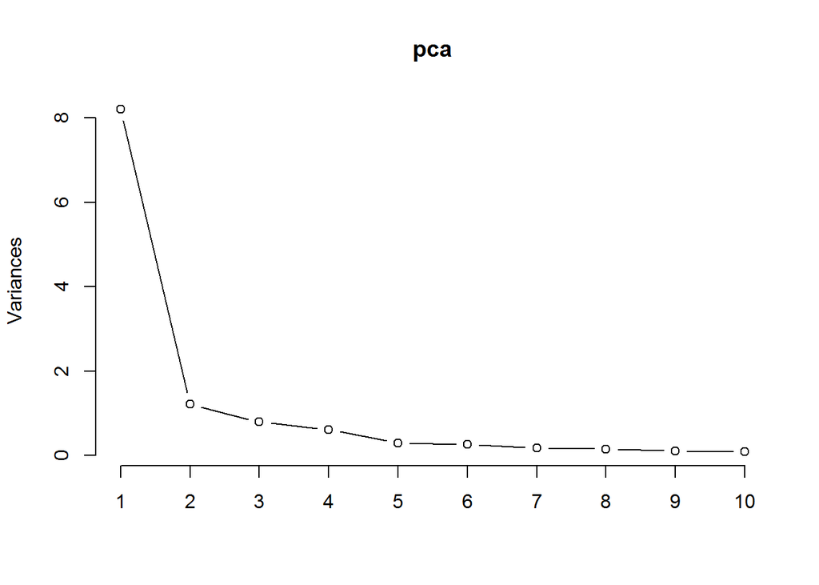

```r
plot(pca, type="l")
```

As can be seen from the table and graph first two components together explain 78.5% of the variability in the data.

```r
df<-data.frame(X, pca$x[,1:2])
cor_mat<-cor(df)
cor_mat<-cor_mat[! rownames(cor_mat)  %in% c("PC1", "PC2"),colnames(cor_mat) %in% c("PC1", "PC2")]
print(cor_mat)
```

```
##                 PC1         PC2
## Pillar.1  0.8817377 -0.31656895
## Pillar.2  0.9325406  0.19304921
## Pillar.3  0.5659094 -0.19343285
## Pillar.4  0.7680200  0.39674769
## Pillar.5  0.8857871  0.28302965
## Pillar.6  0.9154620 -0.23128091
## Pillar.7  0.6868305 -0.58706895
## Pillar.8  0.8303481 -0.21370843
## Pillar.9  0.9220522  0.15310278
## Pillar.10 0.5157673  0.58408300
## Pillar.11 0.9479050  0.02049733
## Pillar.12 0.9178043 -0.01775455
```

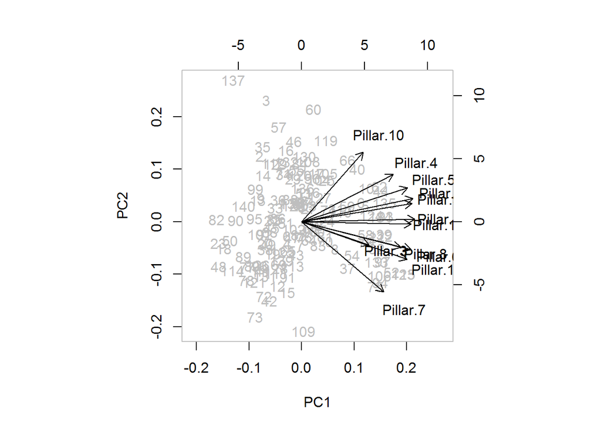

```r
R<- biplot(pca, col = c("gray", "black"))
```

# Q2: Cluster Analysis(hierarchical)

```r
Data1<-as.data.frame(scale(X))
dist<-dist(Data1, method="euclidian")
```

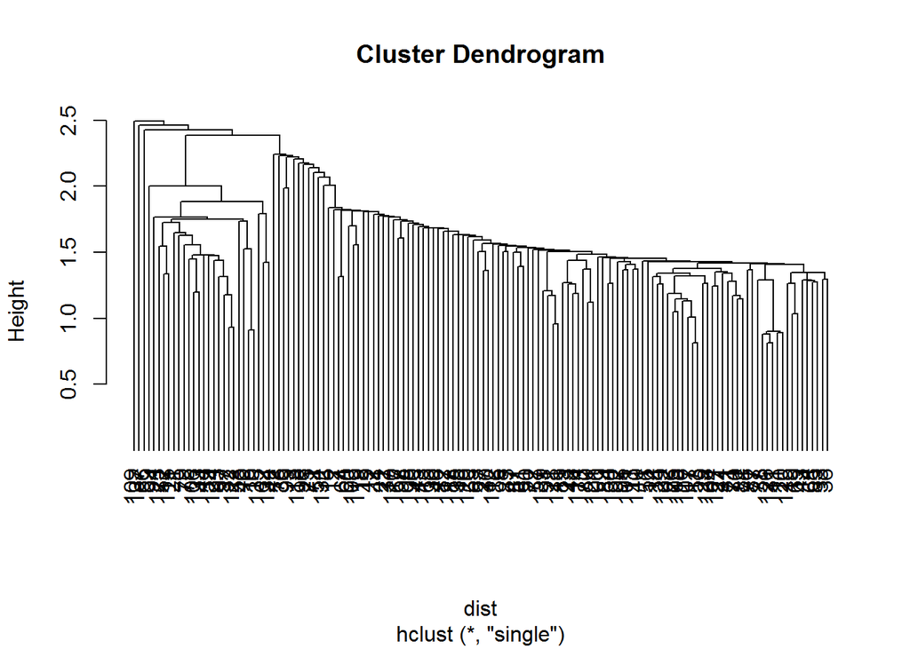

```r
hc<-hclust(dist, method="single")
plot(hc, hang=-1)
```

```r
hc$height
```

```
##   [1] 0.8124078 0.8158176 0.8824732 0.8918446 0.9014263 0.9140413 0.9311568
##   [8] 0.9589345 1.0105668 1.0324663 1.0516491 1.1208270 1.1329591 1.1464463
##  [15] 1.1488648 1.1715182 1.1739270 1.1789887 1.1887344 1.1905014 1.1996931
##  [22] 1.2081387 1.2457570 1.2578446 1.2583308 1.2625735 1.2645455 1.2647465
##  [29] 1.2726715 1.2765007 1.2822629 1.2850859 1.2910668 1.2929006 1.2971761
##  [36] 1.3141293 1.3151128 1.3174694 1.3194128 1.3392518 1.3417332 1.3434581
##  [43] 1.3446802 1.3490427 1.3513636 1.3612614 1.3672033 1.3674137 1.3743120
##  [50] 1.3744209 1.3773513 1.3931049 1.4064010 1.4096401 1.4117106 1.4165421
##  [57] 1.4237438 1.4303159 1.4309242 1.4316644 1.4406503 1.4413426 1.4500339
##  [64] 1.4519457 1.4540097 1.4608201 1.4663179 1.4772155 1.4785022 1.4808033
##  [71] 1.4843533 1.4999225 1.5036329 1.5038154 1.5039019 1.5133380 1.5188373
##  [78] 1.5282582 1.5327434 1.5376501 1.5467613 1.5489507 1.5497068 1.5555731
##  [85] 1.5580883 1.5611086 1.5688141 1.5928324 1.6057145 1.6198762 1.6262357
##  [92] 1.6277939 1.6312626 1.6328541 1.6488907 1.6566891 1.6605071 1.6800568
##  [99] 1.6822029 1.6824950 1.6842840 1.6948009 1.7006930 1.7100780 1.7188094
## [106] 1.7241331 1.7344460 1.7346754 1.7438811 1.7510144 1.7644271 1.7651759
## [113] 1.7714609 1.7788309 1.7889299 1.7919470 1.8065400 1.8086444 1.8134747
## [120] 1.8185609 1.8215026 1.8383371 1.8819173 1.9863703 2.0008667 2.0074405
## [127] 2.0668976 2.1047505 2.1407055 2.1658198 2.1744042 2.2069987 2.2202672
## [134] 2.2298174 2.2432991 2.3847845 2.4266302 2.4603949 2.4912577
```

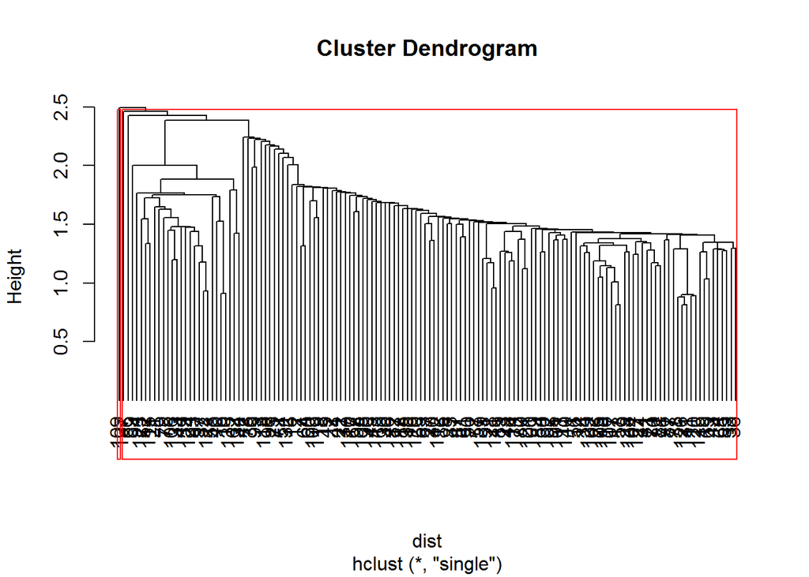

```r
plot(hc, hang=-1)
rect.hclust(hc, 2)
```

The dendogram shows that variables used in data don’t generate significantly different clusters.

```r
Data$Country[109]
```

```
## [1] Rwanda
## 140 Levels: Albania Algeria Argentina Armenia Australia ... Zimbabwe
```

```r
Data$Country[3]
```

```
## [1] Argentina
## 140 Levels: Albania Algeria Argentina Armenia Australia ... Zimbabwe
```

As we can see from the dendogram, the distance between these two clusters which were cut is very small, and one single case (Rwanda) was separated from the others. I have tried to cut 4 clusters as I think the generalization is too much for the other countries.

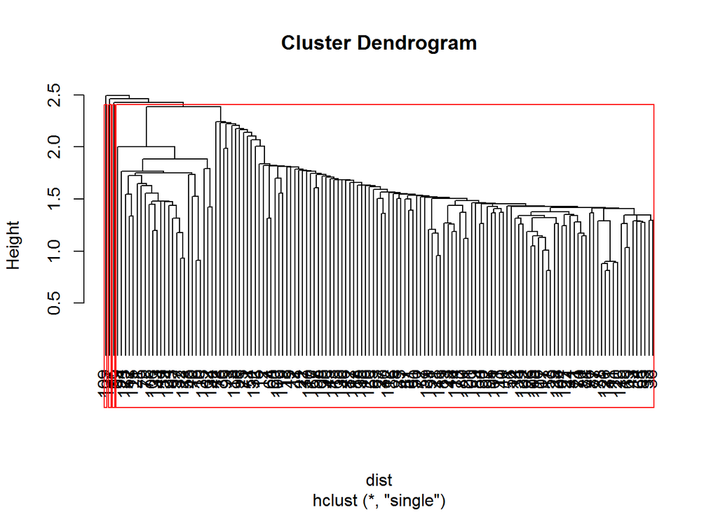

```r
plot(hc, hang=-1)
rect.hclust(hc, 4)
```

Again here is the same problem, therefore I want to have more general clusters which will group several countries.So I will exclude some countries which are too different from others maybe beacause of their social and economical factors, or these countries can be the richest or the poorest ones.

```r
Data$Country[c(109,3,137,35,99,42,8,118,66,78,96,25,54,71,132,59,12)]
```

```
##  [1] Rwanda       Argentina    Venezuela    Egypt        Pakistan
##  [6] Gambia, The  Bahrain      South Africa Korea, Rep.  Malawi
## [11] Nigeria      China        Iceland      Lebanon      Ukraine
## [16] Israel       Bhutan
## 140 Levels: Albania Algeria Argentina Armenia Australia ... Zimbabwe
```

These are countries which do not let the model to comprise more general groups. I will exclude some of them from the data and again do clustering for the remaining countries.

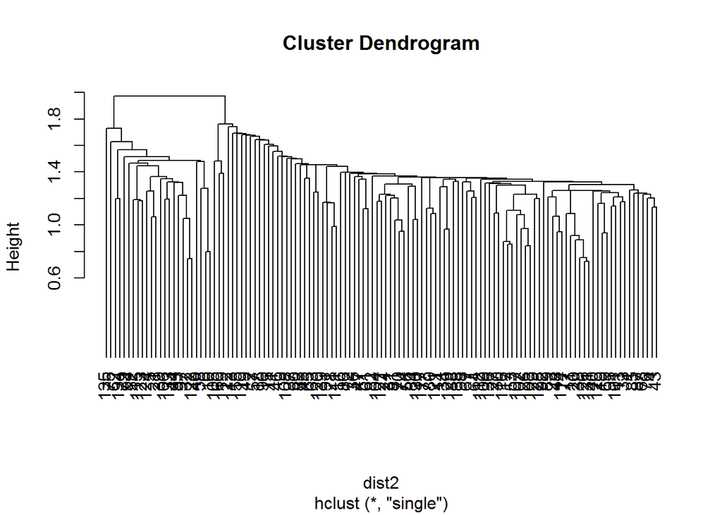

```r
Data2<-Data[-c(109,3,137,35,99,42,8,118,66,78,96,25,54,71,132,59,12),]
dist2<-dist(Data2[3:14], method="euclidian")
hc1<-hclust(dist2, method="single")
plot(hc1, hang=-1)
```

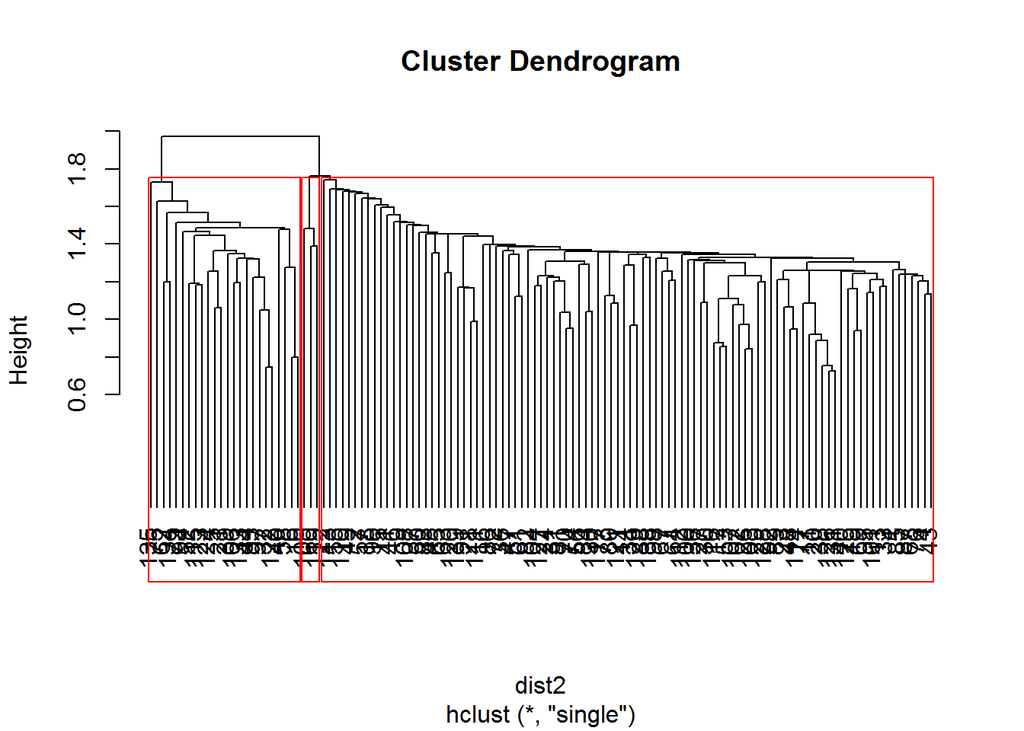

```r
plot(hc1, hang=-1)
rect.hclust(hc1,3)
```

```r
Data2$cl_membership<-cutree(hc1,k=3)
Data2$cl_membership
```

```
##   [1] 1 1 1 2 2 1 1 2 1 1 1 1 1 1 1 1 1 2 1 1 1 1 1 1 1 1 1 2 1 1 1 1 1 2 2
##  [36] 1 1 2 1 1 1 1 1 1 1 2 1 1 1 1 2 3 1 2 1 1 1 1 1 1 1 1 1 1 2 1 1 2 1 1
##  [71] 1 1 1 1 1 1 1 1 1 1 1 2 2 1 2 1 1 1 1 1 1 3 2 1 1 1 1 1 1 1 2 1 1 3 1
## [106] 1 2 2 2 1 1 1 1 1 1 1 2 2 2 1 1 1 1
```

```r
k<-aggregate(Data2[3:14],
             by=list(Data2$cl_membership),
             FUN="mean", na.rm=TRUE)
k
```

```
##   Group.1 Pillar.1 Pillar.2 Pillar.3 Pillar.4 Pillar.5 Pillar.6 Pillar.7
## 1       1 3.719195 3.564237 4.723366 5.262068 3.883904 4.168746 4.048565
## 2       2 5.492289 5.820058 5.591594 6.468119 5.616078 5.222380 4.994505
## 3       3 3.917056 5.613423 3.896796 6.279281 5.024726 4.430135 3.922444
##   Pillar.8 Pillar.9 Pillar.10 Pillar.11 Pillar.12
## 1 3.690502 3.602834  3.560131  3.726489  3.133938
## 2 4.957485 5.888900  4.923018  5.298867  5.049348
## 3 3.480410 5.332357  5.121832  4.523003  3.874859
```

```r
set.seed(1)
k<-kmeans(Data[3:14], 3)
k$centers
```

```
##   Pillar.1 Pillar.2 Pillar.3 Pillar.4 Pillar.5 Pillar.6 Pillar.7 Pillar.8
## 1 3.850423 4.259151 4.770266 5.808045 4.469897 4.334789 4.043611 3.882135
## 2 5.361887 5.721236 5.646327 6.435452 5.559586 5.133026 4.923028 4.827924
## 3 3.535630 2.757856 4.284395 4.595629 3.206918 3.940015 4.030107 3.423007
##   Pillar.9 Pillar.10 Pillar.11 Pillar.12
## 1 4.238769  4.116045  3.987332  3.324294
## 2 5.816609  4.787867  5.186369  4.964957
## 3 2.862880  3.101461  3.465188  2.927322
```

# Q3

I have added 5 variables from the worldbank.org. New variables are GDP, Education expenditures in 2013, Market.Capitalization, Trade, Net Export.

```r
summary(Data[15:19])
```

```
##       GDP         Education.expenditures.2013 Market.Capitalization
##  Min.   :  1.00   Min.   : 0.000              Min.   :  0.00
##  1st Qu.: 34.75   1st Qu.: 0.000              1st Qu.:  0.00
##  Median : 69.50   Median :11.400              Median :  0.00
##  Mean   : 69.68   Mean   : 9.577              Mean   : 27.01
##  3rd Qu.:104.25   3rd Qu.:15.372              3rd Qu.: 41.23
##  Max.   :139.00   Max.   :28.660              Max.   :256.48
##                   NA's   :11                  NA's   :6
##      Trade          Net.Export
##  Min.   : 19.92   Min.   : 0.0000
##  1st Qu.: 46.88   1st Qu.: 0.3009
##  Median : 62.93   Median : 1.5969
##  Mean   : 73.19   Mean   : 5.6721
##  3rd Qu.: 88.13   3rd Qu.: 5.5733
##  Max.   :260.84   Max.   :83.7828
##  NA's   :6        NA's   :6
```

To see how countries in 3 the clusters differ from each other, I have constructed boxplots.

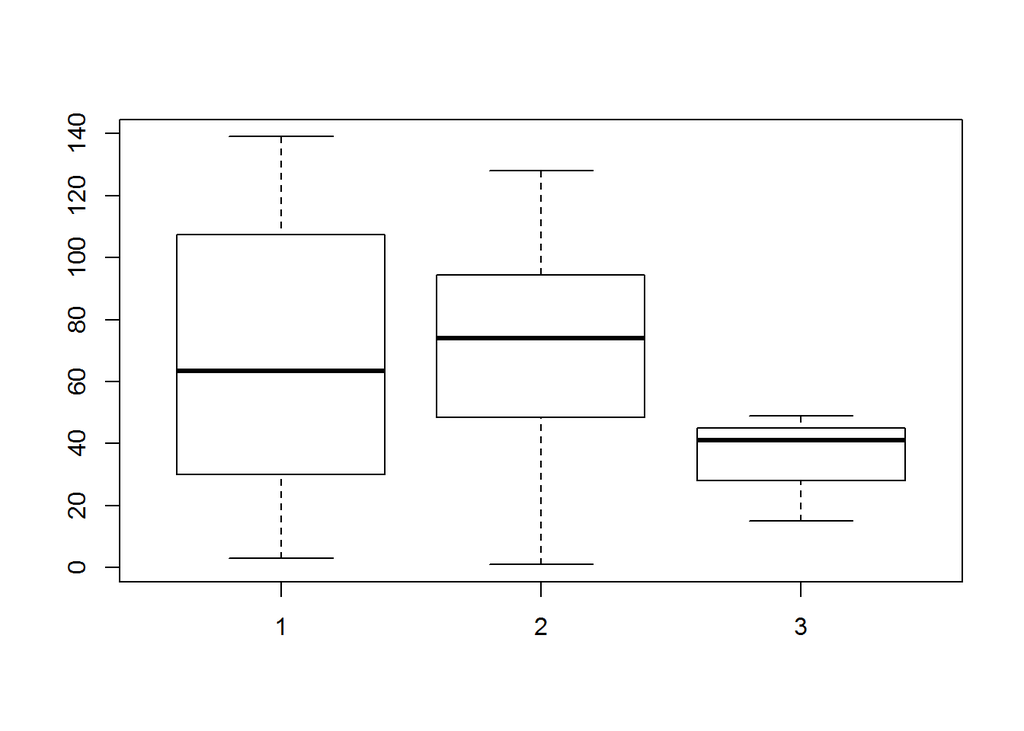

```r
boxplot(Data2$GDP~Data2$cl_membership)
```

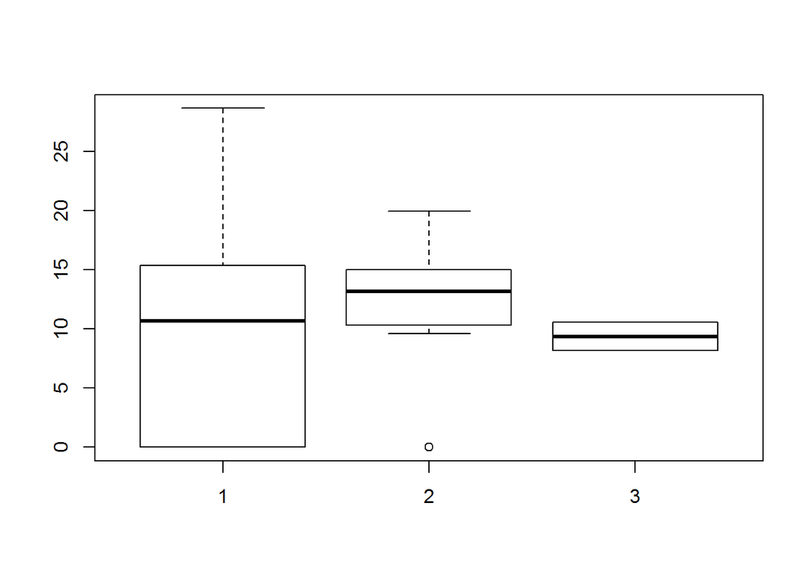

```r
boxplot(Data2$Education.expenditures.2013~Data2$cl_membership)
```

Here we again can see that the second group expends more on education compared with others, so we can continue to name this group as the cluster of high developed countries. The 1st cluster includes transition economies like Russia and for example India as underdeveloped country, so for this group education expenditures varies from very to very high values, but for the 3rd group(developing countries) expenditures don’t vary too much.

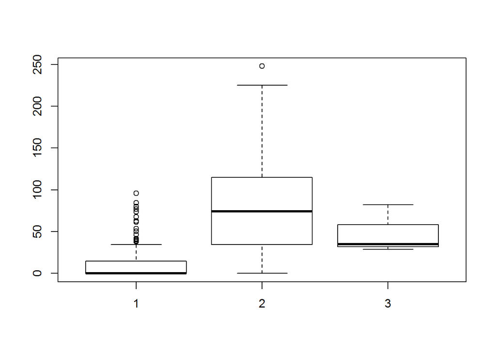

```r
boxplot(Data2$Market.Capitalization~Data2$cl_membership)
```

It is a well known fact that the market capitalization in high developed countries is very high while developing and underdeveloped countries mainly don’t have advanced financial markets.As we can see boxplot of the first group contains a lot of outliers, this is again because these countries have different level of progress and this group contains also countries which can soon transformed from underdeveloped to developing. And as can be seen, the third(developing countries) have higher market capitalization.

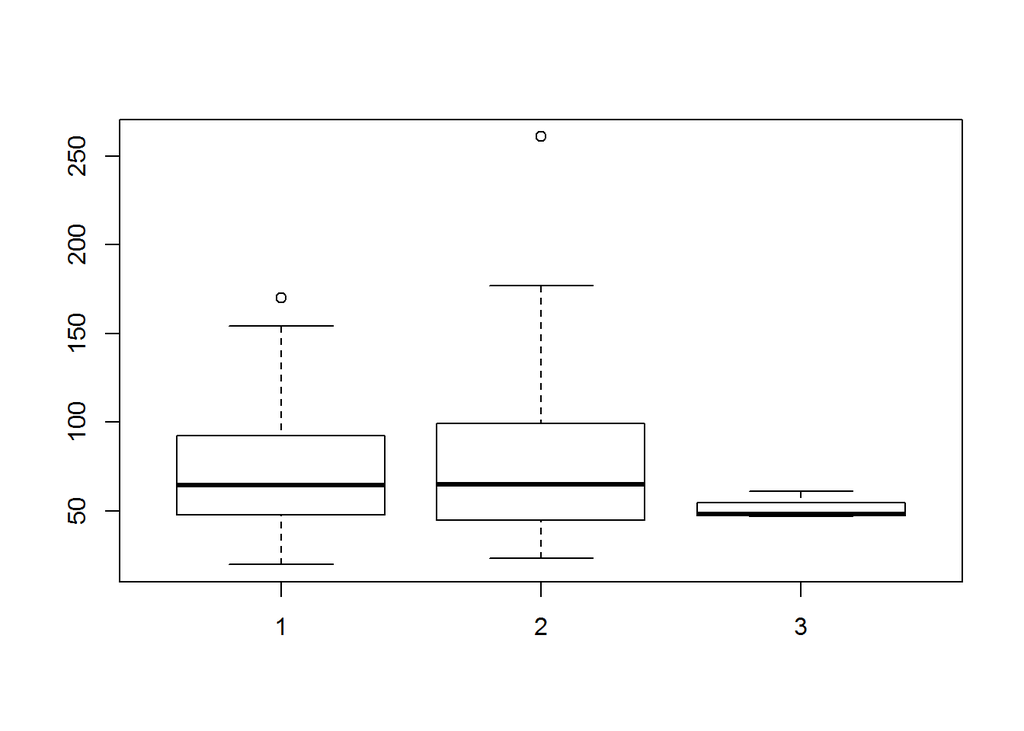

```r
boxplot(Data2$Trade~Data2$cl_membership)
```

As we know, nowadayas the huge part of the world trade accounts for developed countries, and the boxplot again shows that the volumes of trades is a little bit higher for developed contries compared with developing and underdeveloped countries.

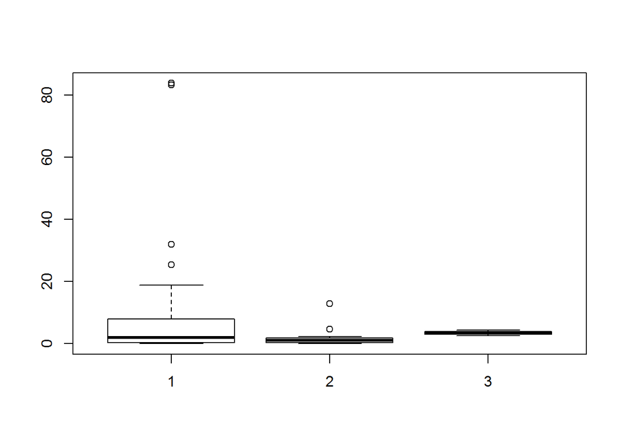

```r
boxplot(Data2$Net.Export~Data2$cl_membership)
```

From the first view it can be seem strange that net export for the developed countries is lower than for developing ones, however this may be result of the fact that the data was given in absolute numbers and volumes of developed countries’ export and import are too high, so the difference(net export) may be lower.

To sum up, taking into account the concepts of The Global Competitiveness Report we made sure that developed countries are more innovative-driven and have very high macroeconomic and socioeconomic indicators while for underdeveloped countries these indicators vary in a high range and on average are lower, and for them the first importance is to satisfy basic requirements so these are mainly factor driven countries which are on the stage of developing main infrustructures and institutions. Developing countries are more efficiency driven and have comparitavely equal level of development.